# Diamond Pricing Analysis

Kenny Ejiogu

2026-08-24

# Project Overview

This project analyzes the `diamonds` dataset included with ggplot2 to explore how diamond characteristics are associated with price. The analysis focuses on carat weight, cut quality, color, and clarity while demonstrating data exploration, visualization, aggregation, and regression in R.

# Research Questions

1. How is diamond price distributed across the dataset?
2. How strongly is carat weight associated with price?
3. How does median price vary across cut quality?
4. How well can carat and cut explain variation in diamond price?

# Data Preparation

```r
diamond_data <- ggplot2::diamonds %>%
  select(carat, cut, color, clarity, depth, table, price, x, y, z) %>%
  drop_na()

glimpse(diamond_data)
```

```
## Rows: 53,940
## Columns: 10
## $ carat   <dbl> 0.23, 0.21, 0.23, 0.29, 0.31, 0.24, 0.24, 0.26, 0.22, 0.23, 0.…
## $ cut     <ord> Ideal, Premium, Good, Premium, Good, Very Good, Very Good, Ver…
## $ color   <ord> E, E, E, I, J, J, I, H, E, H, J, J, F, J, E, E, I, J, J, J, I,…
## $ clarity <ord> SI2, SI1, VS1, VS2, SI2, VVS2, VVS1, SI1, VS2, VS1, SI1, VS1, …
## $ depth   <dbl> 61.5, 59.8, 56.9, 62.4, 63.3, 62.8, 62.3, 61.9, 65.1, 59.4, 64…
## $ table   <dbl> 55, 61, 65, 58, 58, 57, 57, 55, 61, 61, 55, 56, 61, 54, 62, 58…
## $ price   <int> 326, 326, 327, 334, 335, 336, 336, 337, 337, 338, 339, 340, 34…
## $ x       <dbl> 3.95, 3.89, 4.05, 4.20, 4.34, 3.94, 3.95, 4.07, 3.87, 4.00, 4.…
## $ y       <dbl> 3.98, 3.84, 4.07, 4.23, 4.35, 3.96, 3.98, 4.11, 3.78, 4.05, 4.…
## $ z       <dbl> 2.43, 2.31, 2.31, 2.63, 2.75, 2.48, 2.47, 2.53, 2.49, 2.39, 2.…
```

# Summary Statistics

```r
diamond_summary <- diamond_data %>%
  summarise(
    observations = n(),
    average_price = mean(price),
    median_price = median(price),
    average_carat = mean(carat),
    median_carat = median(carat)
  )

diamond_summary
```

| observations | average_price | median_price | average_carat | median_carat |
| --- | --- | --- | --- | --- |
| 53940 | 3932.8 | 2401 | 0.7979397 | 0.7 |

# Visualization 1: Distribution of Diamond Prices

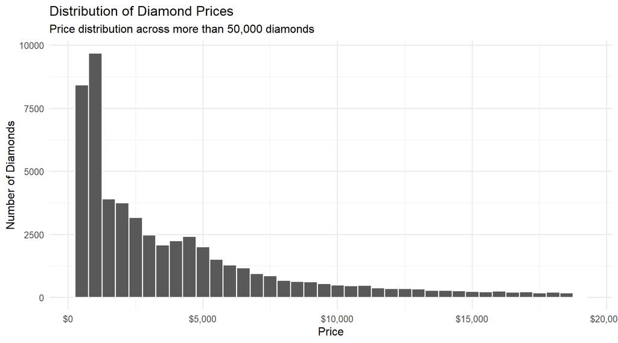

```r
ggplot(diamond_data, aes(x = price)) +
  geom_histogram(binwidth = 500, color = "white") +
  scale_x_continuous(labels = dollar) +
  labs(
    title = "Distribution of Diamond Prices",
    subtitle = "Price distribution across more than 50,000 diamonds",
    x = "Price",
    y = "Number of Diamonds"
  )
```

# Visualization 2: Carat Weight and Price

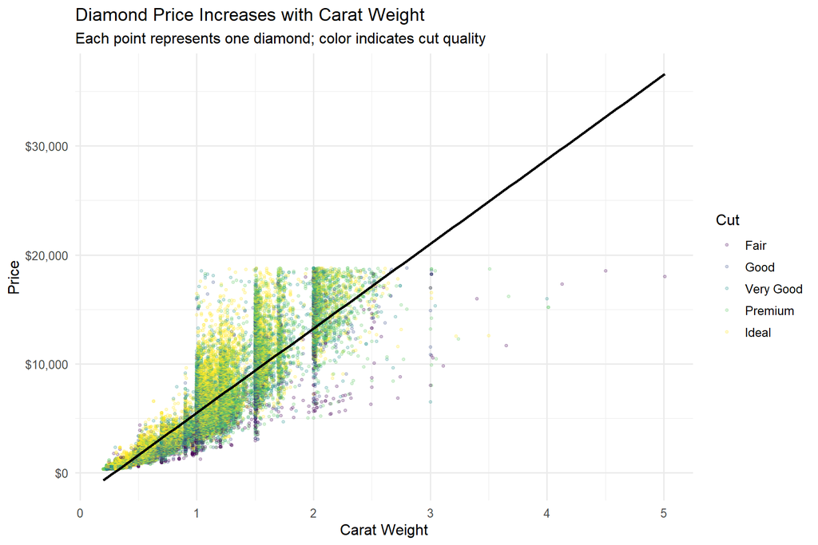

```r
ggplot(diamond_data, aes(x = carat, y = price, color = cut)) +
  geom_point(alpha = 0.20, size = 0.8) +
  geom_smooth(
    aes(group = 1),
    method = "lm",
    se = FALSE,
    color = "black",
    linewidth = 1
  ) +
  scale_y_continuous(labels = dollar) +
  labs(
    title = "Diamond Price Increases with Carat Weight",
    subtitle = "Each point represents one diamond; color indicates cut quality",
    x = "Carat Weight",
    y = "Price",
    color = "Cut"
  )
```

# Visualization 3: Median Price by Cut

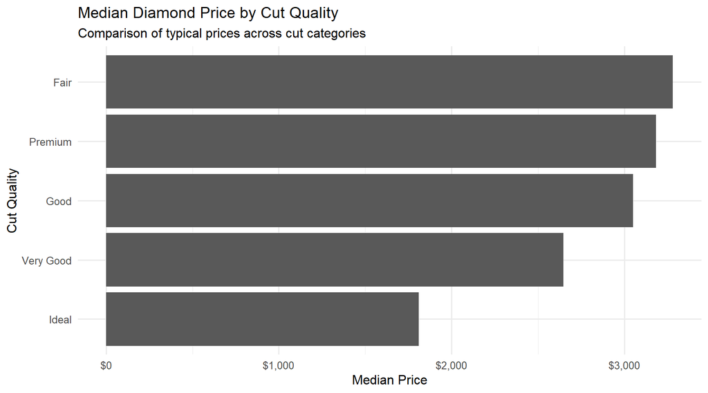

```r
price_by_cut <- diamond_data %>%
  group_by(cut) %>%
  summarise(
    median_price = median(price),
    average_price = mean(price),
    diamond_count = n(),
    .groups = "drop"
  ) %>%
  arrange(desc(median_price))

ggplot(price_by_cut, aes(x = reorder(cut, median_price), y = median_price)) +
  geom_col() +
  coord_flip() +
  scale_y_continuous(labels = dollar) +
  labs(
    title = "Median Diamond Price by Cut Quality",
    subtitle = "Comparison of typical prices across cut categories",
    x = "Cut Quality",
    y = "Median Price"
  )
```

# Visualization 4: Price by Carat Range

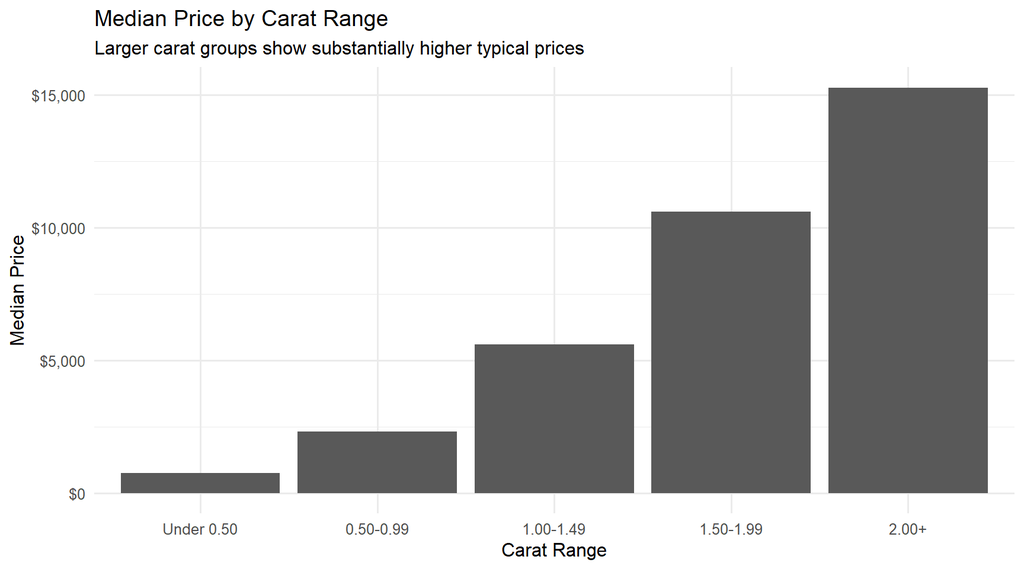

```r
carat_bands <- diamond_data %>%
  mutate(
    carat_group = case_when(
      carat < 0.50 ~ "Under 0.50",
      carat < 1.00 ~ "0.50-0.99",
      carat < 1.50 ~ "1.00-1.49",
      carat < 2.00 ~ "1.50-1.99",
      TRUE ~ "2.00+"
    ),
    carat_group = factor(
      carat_group,
      levels = c("Under 0.50", "0.50-0.99", "1.00-1.49", "1.50-1.99", "2.00+")
    )
  ) %>%
  group_by(carat_group) %>%
  summarise(
    median_price = median(price),
    count = n(),
    .groups = "drop"
  )

ggplot(carat_bands, aes(x = carat_group, y = median_price)) +
  geom_col() +
  scale_y_continuous(labels = dollar) +
  labs(
    title = "Median Price by Carat Range",
    subtitle = "Larger carat groups show substantially higher typical prices",
    x = "Carat Range",
    y = "Median Price"
  )
```

# Statistical Analysis

```r
price_model <- lm(
  price ~ carat + cut,
  data = diamond_data
)

summary(price_model)
```

```
##
## Call:
## lm(formula = price ~ carat + cut, data = diamond_data)
##
## Residuals:
##      Min       1Q   Median       3Q      Max
## -17540.7   -791.6    -37.6    522.1  12721.4
##
## Coefficients:
##             Estimate Std. Error  t value Pr(>|t|)
## (Intercept) -2701.38      15.43 -175.061  < 2e-16 ***
## carat        7871.08      13.98  563.040  < 2e-16 ***
## cut.L        1239.80      26.10   47.502  < 2e-16 ***
## cut.Q        -528.60      23.13  -22.851  < 2e-16 ***
## cut.C         367.91      20.21   18.201  < 2e-16 ***
## cut^4          74.59      16.24    4.593 4.37e-06 ***
## ---
## Signif. codes:  0 '***' 0.001 '**' 0.01 '*' 0.05 '.' 0.1 ' ' 1
##
## Residual standard error: 1511 on 53934 degrees of freedom
## Multiple R-squared:  0.8565, Adjusted R-squared:  0.8565
## F-statistic: 6.437e+04 on 5 and 53934 DF,  p-value: < 2.2e-16
```

# Model Fit

```r
model_fit <- tibble(
  r_squared = summary(price_model)$r.squared,
  adjusted_r_squared = summary(price_model)$adj.r.squared
)

model_fit
```

| r_squared | adjusted_r_squared |
| --- | --- |
| 0.8564748 | 0.8564615 |

# Key Findings

- Diamond prices are strongly associated with carat weight.
- The price distribution is right-skewed, with fewer observations at the highest prices.
- Median prices differ across cut categories, but cut should be interpreted alongside carat because diamond size has a major influence on price.
- Carat-based price bands show a clear increase in typical price as diamond size increases.
- The regression model quantifies the relationship between carat, cut quality, and price.

Because this is an observational dataset, the analysis identifies associations rather than causal relationships.

# Skills Demonstrated

- R
- tidyverse
- ggplot2
- Data cleaning and transformation
- Aggregation and grouped summaries
- Exploratory data analysis
- Data visualization
- Linear regression
- Statistical interpretation
- Analytical communication